# Optimal Treatment Analysis

## Outcome Variable

**Outcome Variable:** ever_stunted

## Predictor Variables

**Intervention Variable:** month

**Adjustment Set:**

unadjusted

## Stratifying Variables

The analysis was stratified on these variable(s):

- agecat
- studyid
- country

## Data Summary

| agecat | studyid | country | month | ever_stunted | n_cell | n |
| --- | --- | --- | --- | --- | --- | --- |
| 0-24 months (no birth st.) | ki0047075b-MAL-ED | BANGLADESH | 1 | 0 | 9 | 217 |
| 0-24 months (no birth st.) | ki0047075b-MAL-ED | BANGLADESH | 1 | 1 | 9 | 217 |
| 0-24 months (no birth st.) | ki0047075b-MAL-ED | BANGLADESH | 2 | 0 | 7 | 217 |
| 0-24 months (no birth st.) | ki0047075b-MAL-ED | BANGLADESH | 2 | 1 | 11 | 217 |
| 0-24 months (no birth st.) | ki0047075b-MAL-ED | BANGLADESH | 3 | 0 | 8 | 217 |
| 0-24 months (no birth st.) | ki0047075b-MAL-ED | BANGLADESH | 3 | 1 | 12 | 217 |
| 0-24 months (no birth st.) | ki0047075b-MAL-ED | BANGLADESH | 4 | 0 | 12 | 217 |
| 0-24 months (no birth st.) | ki0047075b-MAL-ED | BANGLADESH | 4 | 1 | 10 | 217 |
| 0-24 months (no birth st.) | ki0047075b-MAL-ED | BANGLADESH | 5 | 0 | 5 | 217 |
| 0-24 months (no birth st.) | ki0047075b-MAL-ED | BANGLADESH | 5 | 1 | 12 | 217 |
| 0-24 months (no birth st.) | ki0047075b-MAL-ED | BANGLADESH | 6 | 0 | 3 | 217 |
| 0-24 months (no birth st.) | ki0047075b-MAL-ED | BANGLADESH | 6 | 1 | 2 | 217 |
| 0-24 months (no birth st.) | ki0047075b-MAL-ED | BANGLADESH | 7 | 0 | 9 | 217 |
| 0-24 months (no birth st.) | ki0047075b-MAL-ED | BANGLADESH | 7 | 1 | 8 | 217 |
| 0-24 months (no birth st.) | ki0047075b-MAL-ED | BANGLADESH | 8 | 0 | 10 | 217 |
| 0-24 months (no birth st.) | ki0047075b-MAL-ED | BANGLADESH | 8 | 1 | 10 | 217 |
| 0-24 months (no birth st.) | ki0047075b-MAL-ED | BANGLADESH | 9 | 0 | 9 | 217 |
| 0-24 months (no birth st.) | ki0047075b-MAL-ED | BANGLADESH | 9 | 1 | 11 | 217 |
| 0-24 months (no birth st.) | ki0047075b-MAL-ED | BANGLADESH | 10 | 0 | 14 | 217 |
| 0-24 months (no birth st.) | ki0047075b-MAL-ED | BANGLADESH | 10 | 1 | 6 | 217 |
| 0-24 months (no birth st.) | ki0047075b-MAL-ED | BANGLADESH | 11 | 0 | 7 | 217 |
| 0-24 months (no birth st.) | ki0047075b-MAL-ED | BANGLADESH | 11 | 1 | 8 | 217 |
| 0-24 months (no birth st.) | ki0047075b-MAL-ED | BANGLADESH | 12 | 0 | 11 | 217 |
| 0-24 months (no birth st.) | ki0047075b-MAL-ED | BANGLADESH | 12 | 1 | 14 | 217 |
| 0-24 months (no birth st.) | ki0047075b-MAL-ED | BRAZIL | 1 | 0 | 11 | 208 |
| 0-24 months (no birth st.) | ki0047075b-MAL-ED | BRAZIL | 1 | 1 | 2 | 208 |
| 0-24 months (no birth st.) | ki0047075b-MAL-ED | BRAZIL | 2 | 0 | 18 | 208 |
| 0-24 months (no birth st.) | ki0047075b-MAL-ED | BRAZIL | 2 | 1 | 5 | 208 |
| 0-24 months (no birth st.) | ki0047075b-MAL-ED | BRAZIL | 3 | 0 | 18 | 208 |
| 0-24 months (no birth st.) | ki0047075b-MAL-ED | BRAZIL | 3 | 1 | 2 | 208 |

[output cut: 1962 more lines]

The following strata were considered:

- agecat: 0-24 months (no birth st.), studyid: ki0047075b-MAL-ED, country: BANGLADESH
- agecat: 0-24 months (no birth st.), studyid: ki0047075b-MAL-ED, country: BRAZIL
- agecat: 0-24 months (no birth st.), studyid: ki0047075b-MAL-ED, country: INDIA
- agecat: 0-24 months (no birth st.), studyid: ki0047075b-MAL-ED, country: NEPAL
- agecat: 0-24 months (no birth st.), studyid: ki0047075b-MAL-ED, country: PERU
- agecat: 0-24 months (no birth st.), studyid: ki0047075b-MAL-ED, country: SOUTH AFRICA
- agecat: 0-24 months (no birth st.), studyid: ki0047075b-MAL-ED, country: TANZANIA, UNITED REPUBLIC OF
- agecat: 0-24 months (no birth st.), studyid: ki1000108-CMC-V-BCS-2002, country: INDIA
- agecat: 0-24 months (no birth st.), studyid: ki1000108-IRC, country: INDIA
- agecat: 0-24 months (no birth st.), studyid: ki1000109-EE, country: PAKISTAN
- agecat: 0-24 months (no birth st.), studyid: ki1000109-ResPak, country: PAKISTAN
- agecat: 0-24 months (no birth st.), studyid: ki1000304b-SAS-CompFeed, country: INDIA
- agecat: 0-24 months (no birth st.), studyid: ki1000304b-SAS-FoodSuppl, country: INDIA
- agecat: 0-24 months (no birth st.), studyid: ki1017093-NIH-Birth, country: BANGLADESH
- agecat: 0-24 months (no birth st.), studyid: ki1066203-TanzaniaChild2, country: TANZANIA, UNITED REPUBLIC OF
- agecat: 0-24 months (no birth st.), studyid: ki1112895-Guatemala BSC, country: GUATEMALA
- agecat: 0-24 months (no birth st.), studyid: ki1112895-iLiNS-Zinc, country: BURKINA FASO
- agecat: 0-24 months (no birth st.), studyid: ki1113344-GMS-Nepal, country: NEPAL
- agecat: 0-24 months (no birth st.), studyid: ki1114097-CMIN, country: BANGLADESH
- agecat: 0-24 months (no birth st.), studyid: ki1114097-CMIN, country: BRAZIL
- agecat: 0-24 months (no birth st.), studyid: ki1114097-CMIN, country: GUINEA-BISSAU
- agecat: 0-24 months (no birth st.), studyid: ki1114097-CMIN, country: PERU
- agecat: 0-24 months (no birth st.), studyid: ki1114097-CONTENT, country: PERU
- agecat: 0-24 months (no birth st.), studyid: ki1119695-PROBIT, country: BELARUS
- agecat: 0-24 months (no birth st.), studyid: ki1126311-ZVITAMBO, country: ZIMBABWE
- agecat: 0-24 months (no birth st.), studyid: ki1148112-LCNI-5, country: MALAWI
- agecat: 0-24 months (no birth st.), studyid: kiGH5241-JiVitA-3, country: BANGLADESH
- agecat: 0-24 months (no birth st.), studyid: kiGH5241-JiVitA-4, country: BANGLADESH
- agecat: 0-6 months (no birth st.), studyid: ki0047075b-MAL-ED, country: BANGLADESH
- agecat: 0-6 months (no birth st.), studyid: ki0047075b-MAL-ED, country: BRAZIL
- agecat: 0-6 months (no birth st.), studyid: ki0047075b-MAL-ED, country: INDIA
- agecat: 0-6 months (no birth st.), studyid: ki0047075b-MAL-ED, country: NEPAL
- agecat: 0-6 months (no birth st.), studyid: ki0047075b-MAL-ED, country: PERU
- agecat: 0-6 months (no birth st.), studyid: ki0047075b-MAL-ED, country: SOUTH AFRICA
- agecat: 0-6 months (no birth st.), studyid: ki0047075b-MAL-ED, country: TANZANIA, UNITED REPUBLIC OF
- agecat: 0-6 months (no birth st.), studyid: ki1000108-CMC-V-BCS-2002, country: INDIA
- agecat: 0-6 months (no birth st.), studyid: ki1000108-IRC, country: INDIA
- agecat: 0-6 months (no birth st.), studyid: ki1000109-EE, country: PAKISTAN
- agecat: 0-6 months (no birth st.), studyid: ki1000109-ResPak, country: PAKISTAN
- agecat: 0-6 months (no birth st.), studyid: ki1000304b-SAS-CompFeed, country: INDIA
- agecat: 0-6 months (no birth st.), studyid: ki1000304b-SAS-FoodSuppl, country: INDIA
- agecat: 0-6 months (no birth st.), studyid: ki1017093-NIH-Birth, country: BANGLADESH
- agecat: 0-6 months (no birth st.), studyid: ki1066203-TanzaniaChild2, country: TANZANIA, UNITED REPUBLIC OF
- agecat: 0-6 months (no birth st.), studyid: ki1112895-Guatemala BSC, country: GUATEMALA
- agecat: 0-6 months (no birth st.), studyid: ki1113344-GMS-Nepal, country: NEPAL
- agecat: 0-6 months (no birth st.), studyid: ki1114097-CMIN, country: BANGLADESH
- agecat: 0-6 months (no birth st.), studyid: ki1114097-CMIN, country: BRAZIL
- agecat: 0-6 months (no birth st.), studyid: ki1114097-CMIN, country: GUINEA-BISSAU
- agecat: 0-6 months (no birth st.), studyid: ki1114097-CMIN, country: PERU
- agecat: 0-6 months (no birth st.), studyid: ki1114097-CONTENT, country: PERU
- agecat: 0-6 months (no birth st.), studyid: ki1119695-PROBIT, country: BELARUS
- agecat: 0-6 months (no birth st.), studyid: ki1126311-ZVITAMBO, country: ZIMBABWE
- agecat: 0-6 months (no birth st.), studyid: ki1148112-LCNI-5, country: MALAWI
- agecat: 0-6 months (no birth st.), studyid: kiGH5241-JiVitA-3, country: BANGLADESH
- agecat: 0-6 months (no birth st.), studyid: kiGH5241-JiVitA-4, country: BANGLADESH
- agecat: 6-24 months, studyid: ki0047075b-MAL-ED, country: BANGLADESH
- agecat: 6-24 months, studyid: ki0047075b-MAL-ED, country: BRAZIL
- agecat: 6-24 months, studyid: ki0047075b-MAL-ED, country: INDIA
- agecat: 6-24 months, studyid: ki0047075b-MAL-ED, country: NEPAL
- agecat: 6-24 months, studyid: ki0047075b-MAL-ED, country: PERU
- agecat: 6-24 months, studyid: ki0047075b-MAL-ED, country: SOUTH AFRICA
- agecat: 6-24 months, studyid: ki0047075b-MAL-ED, country: TANZANIA, UNITED REPUBLIC OF
- agecat: 6-24 months, studyid: ki1000108-CMC-V-BCS-2002, country: INDIA
- agecat: 6-24 months, studyid: ki1000108-IRC, country: INDIA
- agecat: 6-24 months, studyid: ki1000109-EE, country: PAKISTAN
- agecat: 6-24 months, studyid: ki1000109-ResPak, country: PAKISTAN
- agecat: 6-24 months, studyid: ki1000304b-SAS-CompFeed, country: INDIA
- agecat: 6-24 months, studyid: ki1000304b-SAS-FoodSuppl, country: INDIA
- agecat: 6-24 months, studyid: ki1017093-NIH-Birth, country: BANGLADESH
- agecat: 6-24 months, studyid: ki1066203-TanzaniaChild2, country: TANZANIA, UNITED REPUBLIC OF
- agecat: 6-24 months, studyid: ki1112895-Guatemala BSC, country: GUATEMALA
- agecat: 6-24 months, studyid: ki1112895-iLiNS-Zinc, country: BURKINA FASO
- agecat: 6-24 months, studyid: ki1113344-GMS-Nepal, country: NEPAL
- agecat: 6-24 months, studyid: ki1114097-CMIN, country: BANGLADESH
- agecat: 6-24 months, studyid: ki1114097-CMIN, country: BRAZIL
- agecat: 6-24 months, studyid: ki1114097-CMIN, country: GUINEA-BISSAU
- agecat: 6-24 months, studyid: ki1114097-CMIN, country: PERU
- agecat: 6-24 months, studyid: ki1114097-CONTENT, country: PERU
- agecat: 6-24 months, studyid: ki1119695-PROBIT, country: BELARUS
- agecat: 6-24 months, studyid: ki1126311-ZVITAMBO, country: ZIMBABWE
- agecat: 6-24 months, studyid: ki1148112-LCNI-5, country: MALAWI
- agecat: 6-24 months, studyid: kiGH5241-JiVitA-3, country: BANGLADESH
- agecat: 6-24 months, studyid: kiGH5241-JiVitA-4, country: BANGLADESH

### Dropped Strata

Some strata were dropped due to rare outcomes:

- agecat: 0-24 months (no birth st.), studyid: ki0047075b-MAL-ED, country: BANGLADESH
- agecat: 0-24 months (no birth st.), studyid: ki0047075b-MAL-ED, country: BRAZIL
- agecat: 0-24 months (no birth st.), studyid: ki0047075b-MAL-ED, country: INDIA
- agecat: 0-24 months (no birth st.), studyid: ki0047075b-MAL-ED, country: NEPAL
- agecat: 0-24 months (no birth st.), studyid: ki0047075b-MAL-ED, country: SOUTH AFRICA
- agecat: 0-24 months (no birth st.), studyid: ki0047075b-MAL-ED, country: TANZANIA, UNITED REPUBLIC OF
- agecat: 0-24 months (no birth st.), studyid: ki1000108-CMC-V-BCS-2002, country: INDIA
- agecat: 0-24 months (no birth st.), studyid: ki1000108-IRC, country: INDIA
- agecat: 0-24 months (no birth st.), studyid: ki1000109-EE, country: PAKISTAN
- agecat: 0-24 months (no birth st.), studyid: ki1000109-ResPak, country: PAKISTAN
- agecat: 0-24 months (no birth st.), studyid: ki1000304b-SAS-FoodSuppl, country: INDIA
- agecat: 0-24 months (no birth st.), studyid: ki1112895-Guatemala BSC, country: GUATEMALA
- agecat: 0-24 months (no birth st.), studyid: ki1113344-GMS-Nepal, country: NEPAL
- agecat: 0-24 months (no birth st.), studyid: ki1114097-CMIN, country: BANGLADESH
- agecat: 0-24 months (no birth st.), studyid: ki1114097-CMIN, country: BRAZIL
- agecat: 0-24 months (no birth st.), studyid: ki1114097-CONTENT, country: PERU
- agecat: 0-6 months (no birth st.), studyid: ki0047075b-MAL-ED, country: BANGLADESH
- agecat: 0-6 months (no birth st.), studyid: ki0047075b-MAL-ED, country: BRAZIL
- agecat: 0-6 months (no birth st.), studyid: ki0047075b-MAL-ED, country: INDIA
- agecat: 0-6 months (no birth st.), studyid: ki0047075b-MAL-ED, country: NEPAL
- agecat: 0-6 months (no birth st.), studyid: ki0047075b-MAL-ED, country: PERU
- agecat: 0-6 months (no birth st.), studyid: ki0047075b-MAL-ED, country: SOUTH AFRICA
- agecat: 0-6 months (no birth st.), studyid: ki0047075b-MAL-ED, country: TANZANIA, UNITED REPUBLIC OF
- agecat: 0-6 months (no birth st.), studyid: ki1000108-CMC-V-BCS-2002, country: INDIA
- agecat: 0-6 months (no birth st.), studyid: ki1000109-EE, country: PAKISTAN
- agecat: 0-6 months (no birth st.), studyid: ki1000109-ResPak, country: PAKISTAN
- agecat: 0-6 months (no birth st.), studyid: ki1000304b-SAS-FoodSuppl, country: INDIA
- agecat: 0-6 months (no birth st.), studyid: ki1112895-Guatemala BSC, country: GUATEMALA
- agecat: 0-6 months (no birth st.), studyid: ki1113344-GMS-Nepal, country: NEPAL
- agecat: 0-6 months (no birth st.), studyid: ki1114097-CMIN, country: BANGLADESH
- agecat: 0-6 months (no birth st.), studyid: ki1114097-CMIN, country: BRAZIL
- agecat: 0-6 months (no birth st.), studyid: ki1114097-CMIN, country: GUINEA-BISSAU
- agecat: 0-6 months (no birth st.), studyid: ki1114097-CMIN, country: PERU
- agecat: 0-6 months (no birth st.), studyid: ki1114097-CONTENT, country: PERU
- agecat: 0-6 months (no birth st.), studyid: ki1148112-LCNI-5, country: MALAWI
- agecat: 0-6 months (no birth st.), studyid: kiGH5241-JiVitA-4, country: BANGLADESH
- agecat: 6-24 months, studyid: ki0047075b-MAL-ED, country: BANGLADESH
- agecat: 6-24 months, studyid: ki0047075b-MAL-ED, country: BRAZIL
- agecat: 6-24 months, studyid: ki0047075b-MAL-ED, country: INDIA
- agecat: 6-24 months, studyid: ki0047075b-MAL-ED, country: NEPAL
- agecat: 6-24 months, studyid: ki0047075b-MAL-ED, country: PERU
- agecat: 6-24 months, studyid: ki0047075b-MAL-ED, country: SOUTH AFRICA
- agecat: 6-24 months, studyid: ki0047075b-MAL-ED, country: TANZANIA, UNITED REPUBLIC OF
- agecat: 6-24 months, studyid: ki1000108-CMC-V-BCS-2002, country: INDIA
- agecat: 6-24 months, studyid: ki1000108-IRC, country: INDIA
- agecat: 6-24 months, studyid: ki1000109-EE, country: PAKISTAN
- agecat: 6-24 months, studyid: ki1000109-ResPak, country: PAKISTAN
- agecat: 6-24 months, studyid: ki1000304b-SAS-FoodSuppl, country: INDIA
- agecat: 6-24 months, studyid: ki1112895-Guatemala BSC, country: GUATEMALA
- agecat: 6-24 months, studyid: ki1113344-GMS-Nepal, country: NEPAL
- agecat: 6-24 months, studyid: ki1114097-CMIN, country: BANGLADESH
- agecat: 6-24 months, studyid: ki1114097-CMIN, country: BRAZIL
- agecat: 6-24 months, studyid: ki1114097-CONTENT, country: PERU

## Methods Detail

We’re interested in the causal parameters $E[Y_a]$ for all values of $a \in \mathcal{A}$. These parameters represent the mean outcome if, possibly contrary to fact, we intervened to set all units to have $A=a$. Under the randomization and positivity assumptions, these are identified by the statistical parameters $\psi_a=E_W[E_{Y|A,W}(Y|A=a,W)]$. In addition, we’re interested in the mean of $Y$, $E[Y]$ under no intervention (the observed mean). We will estimate these parameters by using SuperLearner to fit the relevant likelihood factors – $E_{Y|A,W}(Y|A=a,W)$ and $p(A=a|W)$, and then updating our likelihood fit using a joint TMLE.

For unadjusted analyses ($W=\{\}$), initial likelihoods were estimated using Lrnr_glm to estimate the simple $E(Y|A)$ and Lrnr_mean to estimate $p(A)$. For adjusted analyses, a small library containing Lrnr_glmnet, Lrnr_xgboost, and Lrnr_mean was used.

Having estimated these parameters, we will then use the delta method to estimate relative risks and attributable risks relative to a prespecified baseline level of $A$.

# Results Detail

## Results Plots

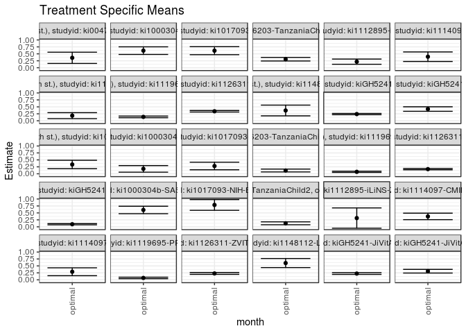

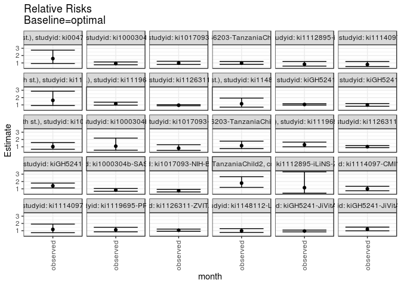

## Results Table

### Parameter: TSM

| agecat | studyid | country | intervention_level | baseline_level | estimate | ci_lower | ci_upper |
| --- | --- | --- | --- | --- | --- | --- | --- |
| 0-24 months (no birth st.) | ki0047075b-MAL-ED | PERU | optimal | NA | 0.3571100 | 0.1549395 | 0.5592805 |
| 0-24 months (no birth st.) | ki1000304b-SAS-CompFeed | INDIA | optimal | NA | 0.6148143 | 0.4776169 | 0.7520116 |
| 0-24 months (no birth st.) | ki1017093-NIH-Birth | BANGLADESH | optimal | NA | 0.6130561 | 0.4691219 | 0.7569903 |
| 0-24 months (no birth st.) | ki1066203-TanzaniaChild2 | TANZANIA, UNITED REPUBLIC OF | optimal | NA | 0.3069346 | 0.2430228 | 0.3708464 |
| 0-24 months (no birth st.) | ki1112895-iLiNS-Zinc | BURKINA FASO | optimal | NA | 0.2180604 | 0.1243704 | 0.3117504 |
| 0-24 months (no birth st.) | ki1114097-CMIN | GUINEA-BISSAU | optimal | NA | 0.3966981 | 0.2252741 | 0.5681220 |
| 0-24 months (no birth st.) | ki1114097-CMIN | PERU | optimal | NA | 0.1837546 | 0.0762076 | 0.2913015 |
| 0-24 months (no birth st.) | ki1119695-PROBIT | BELARUS | optimal | NA | 0.1393905 | 0.1095987 | 0.1691823 |
| 0-24 months (no birth st.) | ki1126311-ZVITAMBO | ZIMBABWE | optimal | NA | 0.3413389 | 0.3132952 | 0.3693826 |
| 0-24 months (no birth st.) | ki1148112-LCNI-5 | MALAWI | optimal | NA | 0.3693994 | 0.1760768 | 0.5627220 |
| 0-24 months (no birth st.) | kiGH5241-JiVitA-3 | BANGLADESH | optimal | NA | 0.2403023 | 0.2179864 | 0.2626182 |
| 0-24 months (no birth st.) | kiGH5241-JiVitA-4 | BANGLADESH | optimal | NA | 0.4212024 | 0.3401667 | 0.5022380 |
| 0-6 months (no birth st.) | ki1000108-IRC | INDIA | optimal | NA | 0.3348886 | 0.1835393 | 0.4862378 |
| 0-6 months (no birth st.) | ki1000304b-SAS-CompFeed | INDIA | optimal | NA | 0.1769937 | 0.0585196 | 0.2954678 |
| 0-6 months (no birth st.) | ki1017093-NIH-Birth | BANGLADESH | optimal | NA | 0.2796101 | 0.1438434 | 0.4153769 |
| 0-6 months (no birth st.) | ki1066203-TanzaniaChild2 | TANZANIA, UNITED REPUBLIC OF | optimal | NA | 0.1178540 | 0.0659855 | 0.1697225 |
| 0-6 months (no birth st.) | ki1119695-PROBIT | BELARUS | optimal | NA | 0.0710861 | 0.0506141 | 0.0915582 |
| 0-6 months (no birth st.) | ki1126311-ZVITAMBO | ZIMBABWE | optimal | NA | 0.1670597 | 0.1436680 | 0.1904514 |
| 0-6 months (no birth st.) | kiGH5241-JiVitA-3 | BANGLADESH | optimal | NA | 0.0930622 | 0.0708434 | 0.1152810 |
| 6-24 months | ki1000304b-SAS-CompFeed | INDIA | optimal | NA | 0.6061265 | 0.4719180 | 0.7403349 |
| 6-24 months | ki1017093-NIH-Birth | BANGLADESH | optimal | NA | 0.7865704 | 0.5934288 | 0.9797120 |
| 6-24 months | ki1066203-TanzaniaChild2 | TANZANIA, UNITED REPUBLIC OF | optimal | NA | 0.1267774 | 0.0744777 | 0.1790772 |
| 6-24 months | ki1112895-iLiNS-Zinc | BURKINA FASO | optimal | NA | 0.3141922 | -0.0509012 | 0.6792856 |
| 6-24 months | ki1114097-CMIN | GUINEA-BISSAU | optimal | NA | 0.3738532 | 0.2571421 | 0.4905644 |
| 6-24 months | ki1114097-CMIN | PERU | optimal | NA | 0.2903931 | 0.1488461 | 0.4319401 |
| 6-24 months | ki1119695-PROBIT | BELARUS | optimal | NA | 0.0683771 | 0.0420397 | 0.0947145 |
| 6-24 months | ki1126311-ZVITAMBO | ZIMBABWE | optimal | NA | 0.2302110 | 0.1967133 | 0.2637088 |
| 6-24 months | ki1148112-LCNI-5 | MALAWI | optimal | NA | 0.6035113 | 0.4408070 | 0.7662156 |
| 6-24 months | kiGH5241-JiVitA-3 | BANGLADESH | optimal | NA | 0.2257858 | 0.1948728 | 0.2566988 |
| 6-24 months | kiGH5241-JiVitA-4 | BANGLADESH | optimal | NA | 0.3103025 | 0.2442692 | 0.3763358 |

### Parameter: E(Y)

| agecat | studyid | country | intervention_level | baseline_level | estimate | ci_lower | ci_upper |
| --- | --- | --- | --- | --- | --- | --- | --- |
| 0-24 months (no birth st.) | ki0047075b-MAL-ED | PERU | observed | NA | 0.5676692 | 0.5080232 | 0.6273151 |
| 0-24 months (no birth st.) | ki1000304b-SAS-CompFeed | INDIA | observed | NA | 0.5660550 | 0.5086421 | 0.6234680 |
| 0-24 months (no birth st.) | ki1017093-NIH-Birth | BANGLADESH | observed | NA | 0.6018868 | 0.5601729 | 0.6436007 |
| 0-24 months (no birth st.) | ki1066203-TanzaniaChild2 | TANZANIA, UNITED REPUBLIC OF | observed | NA | 0.2988814 | 0.2798990 | 0.3178639 |
| 0-24 months (no birth st.) | ki1112895-iLiNS-Zinc | BURKINA FASO | observed | NA | 0.1780497 | 0.1518612 | 0.2042383 |
| 0-24 months (no birth st.) | ki1114097-CMIN | GUINEA-BISSAU | observed | NA | 0.3084337 | 0.2827691 | 0.3340984 |
| 0-24 months (no birth st.) | ki1114097-CMIN | PERU | observed | NA | 0.2976339 | 0.2659904 | 0.3292773 |
| 0-24 months (no birth st.) | ki1119695-PROBIT | BELARUS | observed | NA | 0.1597778 | 0.1408215 | 0.1787342 |
| 0-24 months (no birth st.) | ki1126311-ZVITAMBO | ZIMBABWE | observed | NA | 0.3252945 | 0.3171024 | 0.3334866 |
| 0-24 months (no birth st.) | ki1148112-LCNI-5 | MALAWI | observed | NA | 0.4256121 | 0.3835181 | 0.4677060 |
| 0-24 months (no birth st.) | kiGH5241-JiVitA-3 | BANGLADESH | observed | NA | 0.2535059 | 0.2457125 | 0.2612993 |
| 0-24 months (no birth st.) | kiGH5241-JiVitA-4 | BANGLADESH | observed | NA | 0.4135358 | 0.3953404 | 0.4317312 |
| 0-6 months (no birth st.) | ki1000108-IRC | INDIA | observed | NA | 0.3444444 | 0.2952897 | 0.3935992 |
| 0-6 months (no birth st.) | ki1000304b-SAS-CompFeed | INDIA | observed | NA | 0.1928375 | 0.1691727 | 0.2165022 |
| 0-6 months (no birth st.) | ki1017093-NIH-Birth | BANGLADESH | observed | NA | 0.2283019 | 0.1925336 | 0.2640702 |
| 0-6 months (no birth st.) | ki1066203-TanzaniaChild2 | TANZANIA, UNITED REPUBLIC OF | observed | NA | 0.1369128 | 0.1226581 | 0.1511674 |
| 0-6 months (no birth st.) | ki1119695-PROBIT | BELARUS | observed | NA | 0.0912784 | 0.0781588 | 0.1043979 |
| 0-6 months (no birth st.) | ki1126311-ZVITAMBO | ZIMBABWE | observed | NA | 0.1706248 | 0.1640425 | 0.1772071 |
| 0-6 months (no birth st.) | kiGH5241-JiVitA-3 | BANGLADESH | observed | NA | 0.1311262 | 0.1254944 | 0.1367579 |
| 6-24 months | ki1000304b-SAS-CompFeed | INDIA | observed | NA | 0.5030750 | 0.4588491 | 0.5473009 |
| 6-24 months | ki1017093-NIH-Birth | BANGLADESH | observed | NA | 0.5739130 | 0.5216565 | 0.6261696 |
| 6-24 months | ki1066203-TanzaniaChild2 | TANZANIA, UNITED REPUBLIC OF | observed | NA | 0.2259675 | 0.2054816 | 0.2464534 |
| 6-24 months | ki1112895-iLiNS-Zinc | BURKINA FASO | observed | NA | 0.3623277 | 0.3130786 | 0.4115769 |
| 6-24 months | ki1114097-CMIN | GUINEA-BISSAU | observed | NA | 0.3714710 | 0.3456477 | 0.3972943 |
| 6-24 months | ki1114097-CMIN | PERU | observed | NA | 0.3450439 | 0.3120195 | 0.3780683 |
| 6-24 months | ki1119695-PROBIT | BELARUS | observed | NA | 0.0768510 | 0.0628857 | 0.0908164 |
| 6-24 months | ki1126311-ZVITAMBO | ZIMBABWE | observed | NA | 0.2458438 | 0.2363722 | 0.2553155 |
| 6-24 months | ki1148112-LCNI-5 | MALAWI | observed | NA | 0.6000000 | 0.5644377 | 0.6355623 |
| 6-24 months | kiGH5241-JiVitA-3 | BANGLADESH | observed | NA | 0.2173665 | 0.2079947 | 0.2267384 |
| 6-24 months | kiGH5241-JiVitA-4 | BANGLADESH | observed | NA | 0.3779118 | 0.3593176 | 0.3965059 |

### Parameter: RR

| agecat | studyid | country | intervention_level | baseline_level | estimate | ci_lower | ci_upper |
| --- | --- | --- | --- | --- | --- | --- | --- |
| 0-24 months (no birth st.) | ki0047075b-MAL-ED | PERU | observed | optimal | 1.5896199 | 0.9208343 | 2.7441325 |
| 0-24 months (no birth st.) | ki1000304b-SAS-CompFeed | INDIA | observed | optimal | 0.9206927 | 0.7485396 | 1.1324385 |
| 0-24 months (no birth st.) | ki1017093-NIH-Birth | BANGLADESH | observed | optimal | 0.9817809 | 0.7829762 | 1.2310640 |
| 0-24 months (no birth st.) | ki1066203-TanzaniaChild2 | TANZANIA, UNITED REPUBLIC OF | observed | optimal | 0.9737625 | 0.7978469 | 1.1884655 |
| 0-24 months (no birth st.) | ki1112895-iLiNS-Zinc | BURKINA FASO | observed | optimal | 0.8165158 | 0.5621507 | 1.1859775 |
| 0-24 months (no birth st.) | ki1114097-CMIN | GUINEA-BISSAU | observed | optimal | 0.7775025 | 0.5110675 | 1.1828381 |
| 0-24 months (no birth st.) | ki1114097-CMIN | PERU | observed | optimal | 1.6197358 | 0.9147198 | 2.8681396 |
| 0-24 months (no birth st.) | ki1119695-PROBIT | BELARUS | observed | optimal | 1.1462604 | 0.9618457 | 1.3660330 |
| 0-24 months (no birth st.) | ki1126311-ZVITAMBO | ZIMBABWE | observed | optimal | 0.9529956 | 0.8810890 | 1.0307706 |
| 0-24 months (no birth st.) | ki1148112-LCNI-5 | MALAWI | observed | optimal | 1.1521732 | 0.6893532 | 1.9257227 |
| 0-24 months (no birth st.) | kiGH5241-JiVitA-3 | BANGLADESH | observed | optimal | 1.0549456 | 0.9654438 | 1.1527446 |
| 0-24 months (no birth st.) | kiGH5241-JiVitA-4 | BANGLADESH | observed | optimal | 0.9817983 | 0.8096887 | 1.1904921 |
| 0-6 months (no birth st.) | ki1000108-IRC | INDIA | observed | optimal | 1.0285345 | 0.6696674 | 1.5797146 |
| 0-6 months (no birth st.) | ki1000304b-SAS-CompFeed | INDIA | observed | optimal | 1.0895160 | 0.5408153 | 2.1949180 |
| 0-6 months (no birth st.) | ki1017093-NIH-Birth | BANGLADESH | observed | optimal | 0.8165007 | 0.5149166 | 1.2947213 |
| 0-6 months (no birth st.) | ki1066203-TanzaniaChild2 | TANZANIA, UNITED REPUBLIC OF | observed | optimal | 1.1617149 | 0.7597755 | 1.7762901 |
| 0-6 months (no birth st.) | ki1119695-PROBIT | BELARUS | observed | optimal | 1.2840535 | 1.0019461 | 1.6455908 |
| 0-6 months (no birth st.) | ki1126311-ZVITAMBO | ZIMBABWE | observed | optimal | 1.0213404 | 0.8931249 | 1.1679623 |
| 0-6 months (no birth st.) | kiGH5241-JiVitA-3 | BANGLADESH | observed | optimal | 1.4090167 | 1.1152929 | 1.7800957 |
| 6-24 months | ki1000304b-SAS-CompFeed | INDIA | observed | optimal | 0.8299836 | 0.6619977 | 1.0405969 |
| 6-24 months | ki1017093-NIH-Birth | BANGLADESH | observed | optimal | 0.7296398 | 0.5723021 | 0.9302327 |
| 6-24 months | ki1066203-TanzaniaChild2 | TANZANIA, UNITED REPUBLIC OF | observed | optimal | 1.7823955 | 1.1951673 | 2.6581499 |
| 6-24 months | ki1112895-iLiNS-Zinc | BURKINA FASO | observed | optimal | 1.1532041 | 0.4007813 | 3.3182176 |
| 6-24 months | ki1114097-CMIN | GUINEA-BISSAU | observed | optimal | 0.9936279 | 0.7340427 | 1.3450124 |
| 6-24 months | ki1114097-CMIN | PERU | observed | optimal | 1.1881958 | 0.7389126 | 1.9106582 |
| 6-24 months | ki1119695-PROBIT | BELARUS | observed | optimal | 1.1239296 | 0.8573716 | 1.4733610 |
| 6-24 months | ki1126311-ZVITAMBO | ZIMBABWE | observed | optimal | 1.0679064 | 0.9281278 | 1.2287360 |
| 6-24 months | ki1148112-LCNI-5 | MALAWI | observed | optimal | 0.9941819 | 0.7640378 | 1.2936501 |
| 6-24 months | kiGH5241-JiVitA-3 | BANGLADESH | observed | optimal | 0.9627114 | 0.8471948 | 1.0939789 |
| 6-24 months | kiGH5241-JiVitA-4 | BANGLADESH | observed | optimal | 1.2178817 | 0.9908758 | 1.4968938 |

### Parameter: PAR

| agecat | studyid | country | intervention_level | baseline_level | estimate | ci_lower | ci_upper |
| --- | --- | --- | --- | --- | --- | --- | --- |
| 0-24 months (no birth st.) | ki0047075b-MAL-ED | PERU | optimal | NA | 0.2105592 | 0.0165291 | 0.4045892 |
| 0-24 months (no birth st.) | ki1000304b-SAS-CompFeed | INDIA | optimal | NA | -0.0487592 | -0.1757295 | 0.0782110 |
| 0-24 months (no birth st.) | ki1017093-NIH-Birth | BANGLADESH | optimal | NA | -0.0111693 | -0.1498636 | 0.1275249 |
| 0-24 months (no birth st.) | ki1066203-TanzaniaChild2 | TANZANIA, UNITED REPUBLIC OF | optimal | NA | -0.0080532 | -0.0692047 | 0.0530983 |
| 0-24 months (no birth st.) | ki1112895-iLiNS-Zinc | BURKINA FASO | optimal | NA | -0.0400106 | -0.1228734 | 0.0428522 |
| 0-24 months (no birth st.) | ki1114097-CMIN | GUINEA-BISSAU | optimal | NA | -0.0882643 | -0.2552693 | 0.0787407 |
| 0-24 months (no birth st.) | ki1114097-CMIN | PERU | optimal | NA | 0.1138793 | 0.0086568 | 0.2191017 |
| 0-24 months (no birth st.) | ki1119695-PROBIT | BELARUS | optimal | NA | 0.0203873 | -0.0041335 | 0.0449082 |
| 0-24 months (no birth st.) | ki1126311-ZVITAMBO | ZIMBABWE | optimal | NA | -0.0160444 | -0.0428221 | 0.0107332 |
| 0-24 months (no birth st.) | ki1148112-LCNI-5 | MALAWI | optimal | NA | 0.0562127 | -0.1335966 | 0.2460219 |
| 0-24 months (no birth st.) | kiGH5241-JiVitA-3 | BANGLADESH | optimal | NA | 0.0132036 | -0.0081182 | 0.0345253 |
| 0-24 months (no birth st.) | kiGH5241-JiVitA-4 | BANGLADESH | optimal | NA | -0.0076666 | -0.0888070 | 0.0734738 |
| 0-6 months (no birth st.) | ki1000108-IRC | INDIA | optimal | NA | 0.0095559 | -0.1341571 | 0.1532689 |
| 0-6 months (no birth st.) | ki1000304b-SAS-CompFeed | INDIA | optimal | NA | 0.0158438 | -0.1087893 | 0.1404768 |
| 0-6 months (no birth st.) | ki1017093-NIH-Birth | BANGLADESH | optimal | NA | -0.0513083 | -0.1803919 | 0.0777754 |
| 0-6 months (no birth st.) | ki1066203-TanzaniaChild2 | TANZANIA, UNITED REPUBLIC OF | optimal | NA | 0.0190588 | -0.0309678 | 0.0690853 |
| 0-6 months (no birth st.) | ki1119695-PROBIT | BELARUS | optimal | NA | 0.0201923 | 0.0023498 | 0.0380347 |
| 0-6 months (no birth st.) | ki1126311-ZVITAMBO | ZIMBABWE | optimal | NA | 0.0035651 | -0.0188438 | 0.0259741 |
| 0-6 months (no birth st.) | kiGH5241-JiVitA-3 | BANGLADESH | optimal | NA | 0.0380640 | 0.0162882 | 0.0598397 |
| 6-24 months | ki1000304b-SAS-CompFeed | INDIA | optimal | NA | -0.1030515 | -0.2381661 | 0.0320631 |
| 6-24 months | ki1017093-NIH-Birth | BANGLADESH | optimal | NA | -0.2126574 | -0.4016129 | -0.0237018 |
| 6-24 months | ki1066203-TanzaniaChild2 | TANZANIA, UNITED REPUBLIC OF | optimal | NA | 0.0991901 | 0.0480016 | 0.1503786 |
| 6-24 months | ki1112895-iLiNS-Zinc | BURKINA FASO | optimal | NA | 0.0481355 | -0.2790668 | 0.3753379 |
| 6-24 months | ki1114097-CMIN | GUINEA-BISSAU | optimal | NA | -0.0023822 | -0.1155872 | 0.1108227 |
| 6-24 months | ki1114097-CMIN | PERU | optimal | NA | 0.0546508 | -0.0832278 | 0.1925294 |
| 6-24 months | ki1119695-PROBIT | BELARUS | optimal | NA | 0.0084739 | -0.0094328 | 0.0263807 |
| 6-24 months | ki1126311-ZVITAMBO | ZIMBABWE | optimal | NA | 0.0156328 | -0.0166677 | 0.0479333 |
| 6-24 months | ki1148112-LCNI-5 | MALAWI | optimal | NA | -0.0035113 | -0.1624166 | 0.1553940 |
| 6-24 months | kiGH5241-JiVitA-3 | BANGLADESH | optimal | NA | -0.0084192 | -0.0373002 | 0.0204617 |
| 6-24 months | kiGH5241-JiVitA-4 | BANGLADESH | optimal | NA | 0.0676092 | 0.0035652 | 0.1316533 |

### Parameter: PAF

| agecat | studyid | country | intervention_level | baseline_level | estimate | ci_lower | ci_upper |
| --- | --- | --- | --- | --- | --- | --- | --- |
| 0-24 months (no birth st.) | ki0047075b-MAL-ED | PERU | optimal | NA | 0.3709188 | -0.0859717 | 0.6355861 |
| 0-24 months (no birth st.) | ki1000304b-SAS-CompFeed | INDIA | optimal | NA | -0.0861387 | -0.3359346 | 0.1169498 |
| 0-24 months (no birth st.) | ki1017093-NIH-Birth | BANGLADESH | optimal | NA | -0.0185572 | -0.2771781 | 0.1876945 |
| 0-24 months (no birth st.) | ki1066203-TanzaniaChild2 | TANZANIA, UNITED REPUBLIC OF | optimal | NA | -0.0269444 | -0.2533733 | 0.1585788 |
| 0-24 months (no birth st.) | ki1112895-iLiNS-Zinc | BURKINA FASO | optimal | NA | -0.2247160 | -0.7788824 | 0.1568137 |
| 0-24 months (no birth st.) | ki1114097-CMIN | GUINEA-BISSAU | optimal | NA | -0.2861695 | -0.9566886 | 0.1545757 |
| 0-24 months (no birth st.) | ki1114097-CMIN | PERU | optimal | NA | 0.3826154 | -0.0932310 | 0.6513419 |
| 0-24 months (no birth st.) | ki1119695-PROBIT | BELARUS | optimal | NA | 0.1275979 | -0.0396678 | 0.2679533 |
| 0-24 months (no birth st.) | ki1126311-ZVITAMBO | ZIMBABWE | optimal | NA | -0.0493228 | -0.1349591 | 0.0298520 |
| 0-24 months (no birth st.) | ki1148112-LCNI-5 | MALAWI | optimal | NA | 0.1320749 | -0.4506352 | 0.4807144 |
| 0-24 months (no birth st.) | kiGH5241-JiVitA-3 | BANGLADESH | optimal | NA | 0.0520838 | -0.0357931 | 0.1325052 |
| 0-24 months (no birth st.) | kiGH5241-JiVitA-4 | BANGLADESH | optimal | NA | -0.0185391 | -0.2350426 | 0.1600112 |
| 0-6 months (no birth st.) | ki1000108-IRC | INDIA | optimal | NA | 0.0277429 | -0.4932787 | 0.3669743 |
| 0-6 months (no birth st.) | ki1000304b-SAS-CompFeed | INDIA | optimal | NA | 0.0821613 | -0.8490602 | 0.5444021 |
| 0-6 months (no birth st.) | ki1017093-NIH-Birth | BANGLADESH | optimal | NA | -0.2247386 | -0.9420622 | 0.2276330 |
| 0-6 months (no birth st.) | ki1066203-TanzaniaChild2 | TANZANIA, UNITED REPUBLIC OF | optimal | NA | 0.1392036 | -0.3161783 | 0.4370289 |
| 0-6 months (no birth st.) | ki1119695-PROBIT | BELARUS | optimal | NA | 0.2212162 | 0.0019423 | 0.3923155 |
| 0-6 months (no birth st.) | ki1126311-ZVITAMBO | ZIMBABWE | optimal | NA | 0.0208945 | -0.1196642 | 0.1438080 |
| 0-6 months (no birth st.) | kiGH5241-JiVitA-3 | BANGLADESH | optimal | NA | 0.2902852 | 0.1033746 | 0.4382324 |
| 6-24 months | ki1000304b-SAS-CompFeed | INDIA | optimal | NA | -0.2048431 | -0.5105793 | 0.0390131 |
| 6-24 months | ki1017093-NIH-Birth | BANGLADESH | optimal | NA | -0.3705394 | -0.7473288 | -0.0749998 |
| 6-24 months | ki1066203-TanzaniaChild2 | TANZANIA, UNITED REPUBLIC OF | optimal | NA | 0.4389573 | 0.1632970 | 0.6237985 |
| 6-24 months | ki1112895-iLiNS-Zinc | BURKINA FASO | optimal | NA | 0.1328508 | -1.4951262 | 0.6986334 |
| 6-24 months | ki1114097-CMIN | GUINEA-BISSAU | optimal | NA | -0.0064129 | -0.3623186 | 0.2565124 |
| 6-24 months | ki1114097-CMIN | PERU | optimal | NA | 0.1583879 | -0.3533401 | 0.4766202 |
| 6-24 months | ki1119695-PROBIT | BELARUS | optimal | NA | 0.1102646 | -0.1663554 | 0.3212797 |
| 6-24 months | ki1126311-ZVITAMBO | ZIMBABWE | optimal | NA | 0.0635883 | -0.0774378 | 0.1861555 |
| 6-24 months | ki1148112-LCNI-5 | MALAWI | optimal | NA | -0.0058522 | -0.3088357 | 0.2269935 |
| 6-24 months | kiGH5241-JiVitA-3 | BANGLADESH | optimal | NA | -0.0387329 | -0.1803661 | 0.0859056 |
| 6-24 months | kiGH5241-JiVitA-4 | BANGLADESH | optimal | NA | 0.1789022 | -0.0092082 | 0.3319499 |